# Project 2

Part 1 Load the data and answer the following questions:

How many survey participants were there? What are the data types of each column? What are the top 3 universities with the most survey participants?

```r
# First I import the file and I clean it and convert it in a table
library(janitor)
library(dplyr)
library(stringr)
library(tibble)
library(ggplot2)
library(tidyverse)
library(httr)
library(reshape2)
Conf_Survey <- clean_names(survey) %>%
  as_tibble(rownames_to_column(survey, "id"))
#After I use Glimpse to see the table date
glimpse(Conf_Survey)
```

```
Observations: 30
Variables: 8
$ x                       <int> 0, 1, 2, 3, 4, 5, 6, 7, 8, 9, 10, 11, 12, 13, 14, 15, 16, 1...
$ university              <fct> Delft University of Technology, Eindhoven University of Tec...
$ position                <fct> PhD Student, Head of department, Professor, Assistant Profe...
$ number_of_employees     <int> 15, 20, 10, 191, 34, 79, 71, 75, 54, 10, 16, 9, 9, 12, 48, ...
$ number_of_ph_d_students <int> 4, 8, 3, 120, 20, 33, 34, 42, 28, 2, 7, 0, 0, 10, 3, 220, 1...
$ number_of_postdocs      <int> 6, 2, 1, 47, 10, 13, 16, 21, 14, 3, 2, 2, 5, 0, 10, 20, 12,...
$ number_of_professors    <int> 5, 10, 6, 24, 4, 33, 21, 12, 12, 5, 7, 7, 4, 2, 35, 28, 31,...
$ sizes                   <fct> Small (1 to 20), Small (1 to 20), Small (1 to 20), Extra la...
```

```r
# How many survey participants were there? 30
# WHat are the date types of each column? int,fct, fct, int, int, int,int, fct
# I then group universities and summarise their number to see the top 3 universities
Conf_Survey %>%
  mutate(number=number_of_employees/number_of_employees) %>%
  group_by(university) %>%
  summarise(number=sum(number))
```

| university | number |
| --- | --- |
| Delft University of Technology | 9 |
| Eindhoven University of Technology | 7 |
| Erasmus University Rotterdam | 5 |
| Leiden University | 3 |
| University of Groningen | 6 |

```r
# What are the top 3 universities of participants? Delf, Eindhoven & Groningen
```

Part 2 Obtain a horizontal bar graph of the number of survey participants for the different positions given in the column Position.

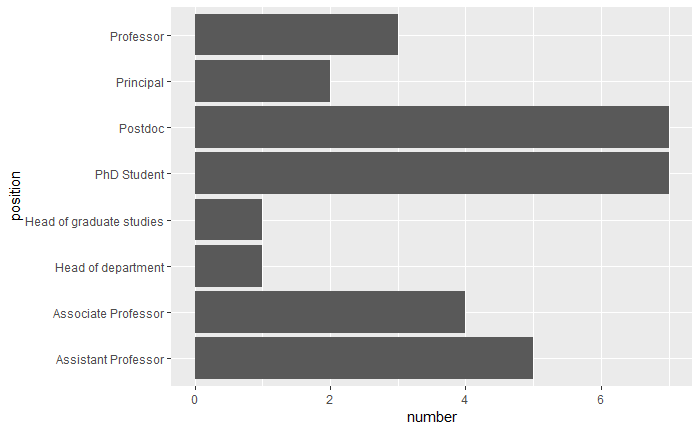

```r
# I create a vector with the info related to the position of the participants to the survey
library(ggplot2)
Position_bar <- Conf_Survey %>%
mutate(number=number_of_employees/number_of_employees) %>%
group_by(position) %>%
summarise(number=sum(number))
# After I create the horizontal graph
ggplot(data=Position_bar, mapping = aes(x=position, y=number)) + geom_bar(stat="identity") + coord_flip()
```

Part 3 Group the data in the column Number of employees in the following bins:

Small (0 to 10) Medium (10 to 20) Large (20 to 100) Extra large(over 100) Then plot a bar chart with {ggplot2} of the number of values in each of the bins.

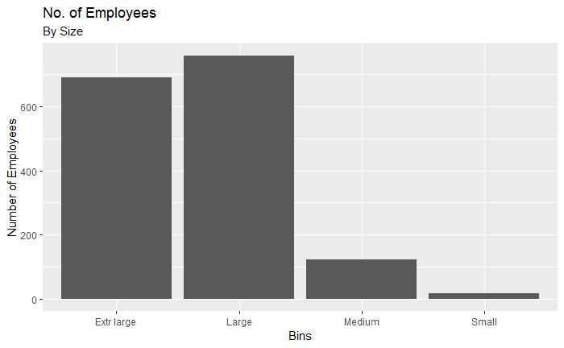

```r
#First I group and arrange the date according to the Number of employees
# AfterI create the bar chart
Conf_Survey %>%
  mutate(bins=case_when(number_of_employees <= 9 ~ "Small", number_of_employees <= 19 ~ "Medium", number_of_employees <= 99 ~ "Large", TRUE ~ "Extr large")) %>% arrange(number_of_employees) %>%
  select(number_of_employees, bins) %>%
  ggplot(mapping = aes(x= bins, y = number_of_employees)) + geom_bar(stat="identity") + labs(title="No. of Employees", subtitle="By Size", x="Bins", y="Number of Employees")
```

Part 4 Obtain a stacked horizontal bar plot with {ggplot2} that gives the percentage of employees that are Ph.D. students, postdocs and professors for each research group. Use a custom theme.

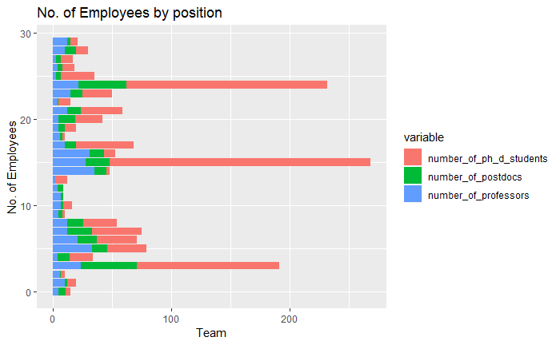

```r
# I create a new table only with the positions and I use mel to create a vairable.
# then I use ggplot to create the chart
Conf_Survey1 <- select(Conf_Survey, 1, 5,6,7)
Conf_Survey2 <- melt(Conf_Survey1, id.var="x")
ggplot(Conf_Survey2, aes(x = x, y = value, fill = variable)) + geom_bar(stat = "identity") + coord_flip() + labs(title = "No. of Employees by position", x = "No. of Employees", y = "Team")
```